# Solution

Relational Data - Data Manipulation (Part 2)

### Exercise 1

Identify the keys in ggplot2::diamonds

**Answer:**

```r
diamonds %>%
  count(carat, cut, color, clarity, depth, table, x, y, z, price) %>%
  filter(n > 1)
```

| carat | cut | color | clarity | depth | table | x | y | z | price | n |
| --- | --- | --- | --- | --- | --- | --- | --- | --- | --- | --- |
| 0.30 | Good | J | VS1 | 63.4 | 57 | 4.23 | 4.26 | 2.69 | 394 | 2 |
| 0.30 | Very Good | G | VS2 | 63.0 | 55 | 4.29 | 4.31 | 2.71 | 526 | 2 |
| 0.30 | Very Good | J | VS1 | 63.4 | 57 | 4.26 | 4.23 | 2.69 | 506 | 2 |
| 0.30 | Premium | D | SI1 | 62.2 | 58 | 4.31 | 4.28 | 2.67 | 709 | 2 |
| 0.30 | Ideal | G | VS2 | 63.0 | 55 | 4.31 | 4.29 | 2.71 | 675 | 2 |
| 0.30 | Ideal | G | IF | 62.1 | 55 | 4.32 | 4.35 | 2.69 | 863 | 2 |
| 0.30 | Ideal | H | SI1 | 62.2 | 57 | 4.26 | 4.29 | 2.66 | 450 | 2 |
| 0.30 | Ideal | H | SI1 | 62.2 | 57 | 4.27 | 4.28 | 2.66 | 450 | 2 |
| 0.31 | Good | D | SI1 | 63.5 | 56 | 4.29 | 4.31 | 2.73 | 571 | 2 |
| 0.31 | Very Good | D | SI1 | 63.5 | 56 | 4.31 | 4.29 | 2.73 | 732 | 2 |

[output cut: 133 more lines]

Even if grouped by all the variables we still see that there are groups with more than one record. We have duplicates. We can also draw the same conclusion by checking the number of rows and number of unique records:

```r
nrow(diamonds)
```

```
[1] 53940
```

```r
nrow(unique(diamonds))
```

```
[1] 53794
```

We could instead use a row number to distinguish between records:

```r
diamonds %>%
  mutate(row_n = row_number())
```

| carat | cut | color | clarity | depth | table | price | x | y | z | row_n |
| --- | --- | --- | --- | --- | --- | --- | --- | --- | --- | --- |
| 0.23 | Ideal | E | SI2 | 61.5 | 55.0 | 326 | 3.95 | 3.98 | 2.43 | 1 |
| 0.21 | Premium | E | SI1 | 59.8 | 61.0 | 326 | 3.89 | 3.84 | 2.31 | 2 |
| 0.23 | Good | E | VS1 | 56.9 | 65.0 | 327 | 4.05 | 4.07 | 2.31 | 3 |
| 0.29 | Premium | I | VS2 | 62.4 | 58.0 | 334 | 4.20 | 4.23 | 2.63 | 4 |
| 0.31 | Good | J | SI2 | 63.3 | 58.0 | 335 | 4.34 | 4.35 | 2.75 | 5 |
| 0.24 | Very Good | J | VVS2 | 62.8 | 57.0 | 336 | 3.94 | 3.96 | 2.48 | 6 |
| 0.24 | Very Good | I | VVS1 | 62.3 | 57.0 | 336 | 3.95 | 3.98 | 2.47 | 7 |
| 0.26 | Very Good | H | SI1 | 61.9 | 55.0 | 337 | 4.07 | 4.11 | 2.53 | 8 |
| 0.22 | Fair | E | VS2 | 65.1 | 61.0 | 337 | 3.87 | 3.78 | 2.49 | 9 |
| 0.23 | Very Good | H | VS1 | 59.4 | 61.0 | 338 | 4.00 | 4.05 | 2.39 | 10 |

[output cut: 990 more lines]

### Exercise 2

Add the location of the origin and destination (i.e. the `lat` and `lon`) to flights.

**Answer:**

```r
airport_locations <- airports %>%
  select(faa, lat, lon)

flights %>%
  select(year:day, hour, origin, dest) %>%
  left_join(airport_locations, by = c("origin" = "faa")) %>%
  left_join(airport_locations, by = c("dest" = "faa"))
```

| year | month | day | hour | origin | dest | lat.x | lon.x | lat.y | lon.y |
| --- | --- | --- | --- | --- | --- | --- | --- | --- | --- |
| 2013 | 1 | 1 | 5 | EWR | IAH | 40.69250 | -74.16867 | 29.98443 | -95.34144 |
| 2013 | 1 | 1 | 5 | LGA | IAH | 40.77725 | -73.87261 | 29.98443 | -95.34144 |
| 2013 | 1 | 1 | 5 | JFK | MIA | 40.63975 | -73.77893 | 25.79325 | -80.29056 |
| 2013 | 1 | 1 | 5 | JFK | BQN | 40.63975 | -73.77893 | NA | NA |
| 2013 | 1 | 1 | 6 | LGA | ATL | 40.77725 | -73.87261 | 33.63672 | -84.42807 |
| 2013 | 1 | 1 | 5 | EWR | ORD | 40.69250 | -74.16867 | 41.97860 | -87.90484 |
| 2013 | 1 | 1 | 6 | EWR | FLL | 40.69250 | -74.16867 | 26.07258 | -80.15275 |
| 2013 | 1 | 1 | 6 | LGA | IAD | 40.77725 | -73.87261 | 38.94453 | -77.45581 |
| 2013 | 1 | 1 | 6 | JFK | MCO | 40.63975 | -73.77893 | 28.42939 | -81.30899 |
| 2013 | 1 | 1 | 6 | LGA | ORD | 40.77725 | -73.87261 | 41.97860 | -87.90484 |

[output cut: 990 more lines]

This default can be overridden using the `suffix` argument:

```r
flights %>%
  select(year:day, hour, origin, dest) %>%
  left_join(airport_locations, by = c("origin" = "faa")) %>%
  left_join(airport_locations, by = c("dest" = "faa"),
           suffix = c(".origin", ".dest")) %>%
  print
```

| year | month | day | hour | origin | dest | lat.origin | lon.origin | lat.dest | lon.dest |
| --- | --- | --- | --- | --- | --- | --- | --- | --- | --- |
| 2013 | 1 | 1 | 5 | EWR | IAH | 40.69250 | -74.16867 | 29.98443 | -95.34144 |
| 2013 | 1 | 1 | 5 | LGA | IAH | 40.77725 | -73.87261 | 29.98443 | -95.34144 |
| 2013 | 1 | 1 | 5 | JFK | MIA | 40.63975 | -73.77893 | 25.79325 | -80.29056 |
| 2013 | 1 | 1 | 5 | JFK | BQN | 40.63975 | -73.77893 | NA | NA |
| 2013 | 1 | 1 | 6 | LGA | ATL | 40.77725 | -73.87261 | 33.63672 | -84.42807 |
| 2013 | 1 | 1 | 5 | EWR | ORD | 40.69250 | -74.16867 | 41.97860 | -87.90484 |
| 2013 | 1 | 1 | 6 | EWR | FLL | 40.69250 | -74.16867 | 26.07258 | -80.15275 |
| 2013 | 1 | 1 | 6 | LGA | IAD | 40.77725 | -73.87261 | 38.94453 | -77.45581 |
| 2013 | 1 | 1 | 6 | JFK | MCO | 40.63975 | -73.77893 | 28.42939 | -81.30899 |
| 2013 | 1 | 1 | 6 | LGA | ORD | 40.77725 | -73.87261 | 41.97860 | -87.90484 |

[output cut: 990 more lines]

### Exercise 3

What happened on June 13 2013? Display the spatial pattern of delays, and then use Google to cross-reference with the weather.

Hint: Use the following code as a template for creating a simple US map and annotate it with useful information.

Note: You may need to install/load **maps** library.

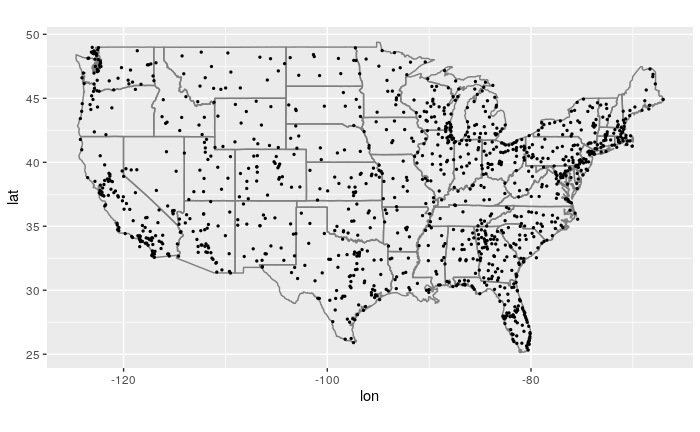

```r
airports %>%
  filter(lon < 0 & between(lat, 25, 50)) %>%  # limiting the map to US mainland boarders for clarity
  ggplot(aes(lon, lat)) +
    borders("state") +
    geom_point(size = 0.5) +
    coord_quickmap()
```

**Answer:**

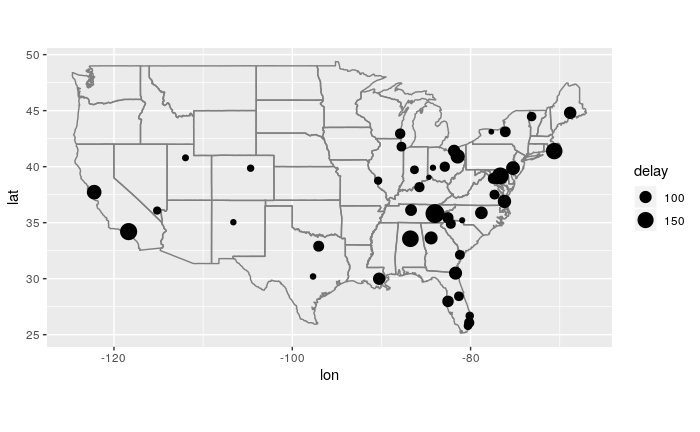

```r
flights %>%
  filter(year == 2013, month == 6, day == 13) %>%  # June 13 2013
  group_by(dest) %>%
  summarise(delay = mean(arr_delay, na.rm = TRUE)) %>%
  inner_join(airports, by = c("dest" = "faa")) %>%
  filter(lon < 0 & between(lat, 25, 50)) %>%  # limiting the map to US mainland boarders for clarity
  filter(delay > 60) %>%  # only destinations with delays more than one hour
  ggplot(aes(y = lat, x = lon, size = delay)) +
    borders("state") +
    geom_point() +
    coord_quickmap()
```

We can also map the percentage of the flights that were canceled per destination, we see a similar pattern:

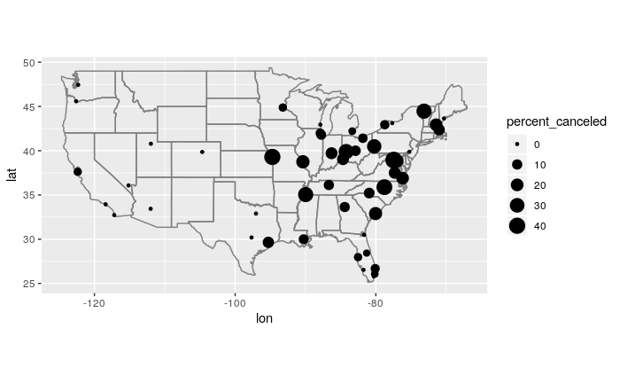

```r
flights %>%
  filter(year == 2013, month == 6, day == 13) %>%  # June 13 2013
  group_by(dest) %>%
  summarize(percent_canceled = sum(is.na(dep_delay))/n() * 100,
           n = n()) %>%
  filter(n >= 5) %>%  # keeping destinations that at least had 5 flights from NYC that day
  inner_join(airports, by = c("dest" = "faa")) %>%
  filter(lon < 0 & between(lat, 25, 50)) %>%  # limiting the map to US mainland boarders for clarity
  ggplot(aes(y = lat, x = lon, size = percent_canceled)) +
    borders("state") +
    geom_point() +
    coord_quickmap()
```

### Exercise 4

What does it mean for a flight to have a missing `tailnum`? What do the tail numbers that don’t have a matching record in planes have in common? (Hint: one variable explains ~90% of the problems.)

**Asnwer:**

American Airlines (AA) and Envoy Airlines (MQ) don’t report tail numbers.

```r
flights %>%
  anti_join(planes, by = "tailnum") %>%
  count(carrier, sort = TRUE)
```

| carrier | n |
| --- | --- |
| MQ | 25397 |
| AA | 22558 |
| UA | 1693 |
| 9E | 1044 |
| B6 | 830 |
| US | 699 |
| FL | 187 |
| DL | 110 |
| F9 | 50 |
| WN | 38 |

### Exercise 5

Filter `flights` to only show those with planes that have flown at least 100 flights.

***Answer:**

```r
planes_w_over_100 <- flights %>%
  group_by(tailnum) %>%
  count() %>%
  filter(n > 100)
```

```r
flights %>%
  semi_join(planes_w_over_100, by = "tailnum")
```

| year | month | day | dep_time | sched_dep_time | dep_delay | arr_time | sched_arr_time | arr_delay | carrier | flight | tailnum | origin | dest | air_time | distance | hour | minute | time_hour |
| --- | --- | --- | --- | --- | --- | --- | --- | --- | --- | --- | --- | --- | --- | --- | --- | --- | --- | --- |
| 2013 | 1 | 1 | 517 | 515 | 2 | 830 | 819 | 11 | UA | 1545 | N14228 | EWR | IAH | 227 | 1400 | 5 | 15 | 2013-01-01 05:00:00 |
| 2013 | 1 | 1 | 533 | 529 | 4 | 850 | 830 | 20 | UA | 1714 | N24211 | LGA | IAH | 227 | 1416 | 5 | 29 | 2013-01-01 05:00:00 |
| 2013 | 1 | 1 | 544 | 545 | -1 | 1004 | 1022 | -18 | B6 | 725 | N804JB | JFK | BQN | 183 | 1576 | 5 | 45 | 2013-01-01 05:00:00 |
| 2013 | 1 | 1 | 554 | 558 | -4 | 740 | 728 | 12 | UA | 1696 | N39463 | EWR | ORD | 150 | 719 | 5 | 58 | 2013-01-01 05:00:00 |
| 2013 | 1 | 1 | 555 | 600 | -5 | 913 | 854 | 19 | B6 | 507 | N516JB | EWR | FLL | 158 | 1065 | 6 | 0 | 2013-01-01 06:00:00 |
| 2013 | 1 | 1 | 557 | 600 | -3 | 709 | 723 | -14 | EV | 5708 | N829AS | LGA | IAD | 53 | 229 | 6 | 0 | 2013-01-01 06:00:00 |
| 2013 | 1 | 1 | 557 | 600 | -3 | 838 | 846 | -8 | B6 | 79 | N593JB | JFK | MCO | 140 | 944 | 6 | 0 | 2013-01-01 06:00:00 |
| 2013 | 1 | 1 | 558 | 600 | -2 | 849 | 851 | -2 | B6 | 49 | N793JB | JFK | PBI | 149 | 1028 | 6 | 0 | 2013-01-01 06:00:00 |
| 2013 | 1 | 1 | 558 | 600 | -2 | 853 | 856 | -3 | B6 | 71 | N657JB | JFK | TPA | 158 | 1005 | 6 | 0 | 2013-01-01 06:00:00 |
| 2013 | 1 | 1 | 558 | 600 | -2 | 923 | 937 | -14 | UA | 1124 | N53441 | EWR | SFO | 361 | 2565 | 6 | 0 | 2013-01-01 06:00:00 |

[output cut: 990 more lines]

### Exercise 6

- What does `anti_join(flights, airports, by = c("dest" = "faa"))` tell you?
- What does `anti_join(airports, flights, by = c("faa" = "dest"))` tell you?

**Answer:**

- `anti_join(flights, airports, by = c("dest" = "faa"))` are flights that go to an airport that is not in FAA list of destinations, likely foreign airports.
- `anti_join(airports, flights, by = c("faa" = "dest"))` are US airports that don’t have a flight in the data, meaning that there were no flights to that airport directly from New York in 2013.